# COVARIANCE & CORRELATION

D

Aug 23rd, 2016

## Intro

In tihs file we esplore the definitions of correlation and covariance and their relationships.

# Covariance

Covariance is a measure of association (as a matter of fact, one of the many measures of association) between two variabiles, i.e. how much the tow vars change together. In plain words, “association” can manifest itself in terms of one var getting greater values and the other getting greater values, or one var getting grater values and the other getting smaller values. Covariance tries to capture this phenomena, its strenght and its direction: measures the extent to which two variables change together.

“Linear change” means that a change in one var is associated witha change in the second var the is proportional to the change in the first variable.

Suppose you have a N-sized sample of two vars, x and y. The covariance between them is:

$s_{xy} = Cov(x, y) = \frac{\sum_{i=1}^{N} (x_i - \bar{x})(y_i - \bar{y})}{N - 1}$

Each addend in the numerator is the product of the deviation of each observation from the mean. The rationale is as follows: if there is an association between $x$ and $y$, i.e. as $x$ increases $y$ gets larger as well, both $(x_i - \bar{x})$ and $(y_i - \bar{y})$ will be positive or both will be negative, this way their sum will increase (in amplitude).

Viceversa, if $x$ and $y$ are not associated, the sign of $(x_i - \bar{x})$ and the sign of $(y_i - \bar{y})$ sometimes will be negative, other times positive. Thus the sum of them over the several datapoints will be a small number (in amplitude).

This sum is divided by $N - 1$: it’s averaged by the nmumber of datapoints. Since data is declared as sampled from a population, we do not divide by the size of the sample ($N$, that would be the size of population as well), but by $N - 1$ since we used data to compute the mean $\bar{x}$ (and $\bar{y}$). So we are left with $N - 1$ degrees of freedom.

# The data

```r
x = c(1, 2, 3, 4, 5, 6, 7, 8, 9, 10)
y_1 = x
```

Data is composed of 2 vectors of 10 datapoints each. Data is clearly artificial, but it is build only to show some features of the covariance and correlation concepts.

```r
library(knitr)
kable(data.frame(x = x, y = y_1), digits = 2)
```

| x | y |
| --- | --- |
| 1 | 1 |
| 2 | 2 |
| 3 | 3 |
| 4 | 4 |
| 5 | 5 |
| 6 | 6 |
| 7 | 7 |
| 8 | 8 |
| 9 | 9 |
| 10 | 10 |

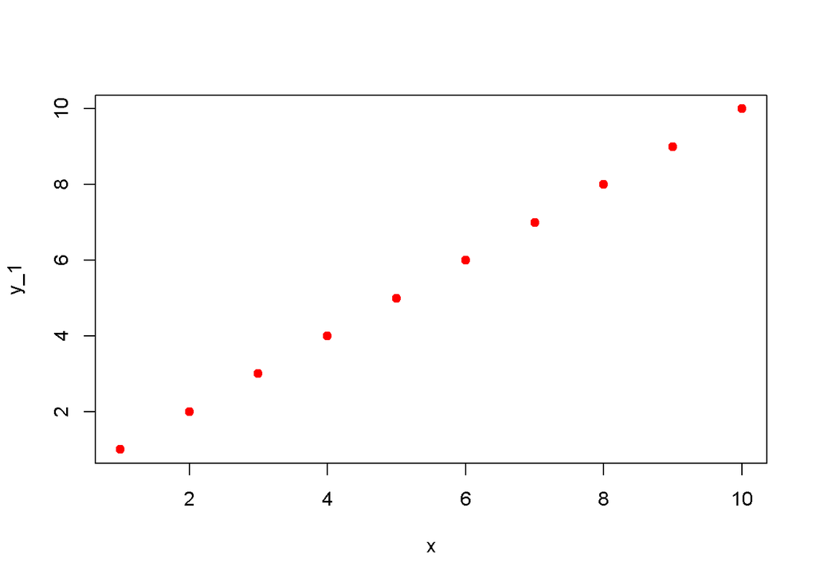

```r
plot(x, y_1, pch = 19, col = 'red')
```

There is clearly an association between the two vars, since as x increases, y follows increasing. This intuitive observation is captured by the covariance. This can be computed using the definition:

$Cov(x, y_1) = 9.1666667$

Covariance is positive, greater that zero, indicating that as $x$ increaes, $y_1$ increaeses as well.

R has a function to compute the covariance, called, unsusprisingly, cov:

```r
cov_x_y_1_r = cov(x, y_1)
cov_x_y_1_r
```

```
## [1] 9.166667
```

and the result is the same we got using the definition. By the way this tells us that the R’s cov function computes sample covariances, not population covariances.

Let’s try to compute covariance for this second data set:

```r
x = c(1, 2, 3, 4, 5, 6, 7, 8, 9, 10)
y_2 = -x

kable(data.frame(x = x, y = y_2), digits = 2)
```

| x | y |
| --- | --- |
| 1 | -1 |
| 2 | -2 |
| 3 | -3 |
| 4 | -4 |
| 5 | -5 |
| 6 | -6 |
| 7 | -7 |
| 8 | -8 |
| 9 | -9 |
| 10 | -10 |

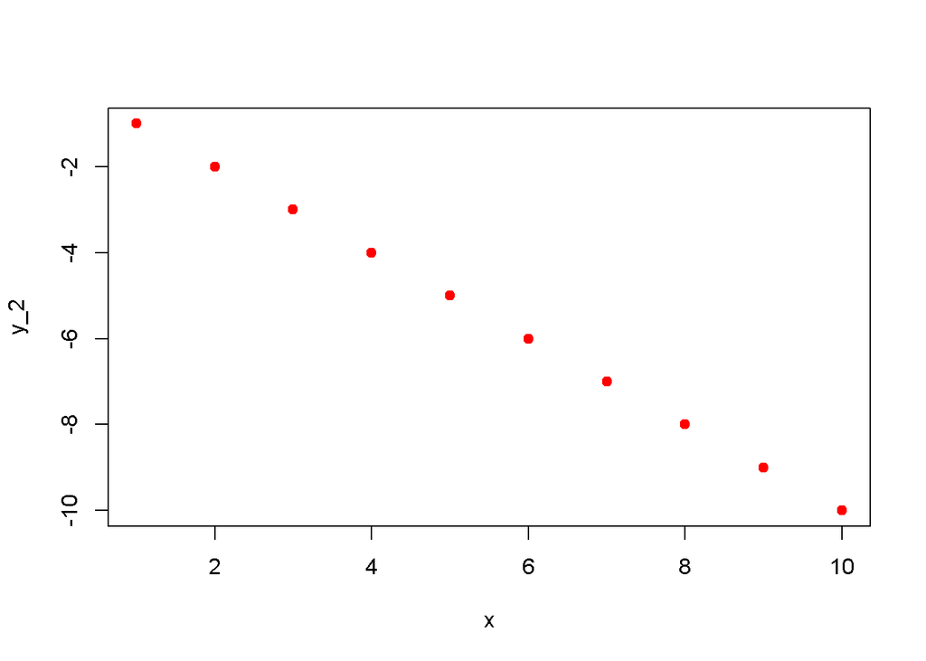

```r
plot(x, y_2, pch = 19, col = 'red')
```

The plot tells us that there is in fact an association between the two vars.

$Cov(x, y_2) = -9.1666667$

The value is not zero confirming that this association is captured by covariance. Negative value means that as $x$ increses, $y$ decreases and viceversa.

Let’s consider these other datasets:

```r
x_3 = x*100
y_3 = x_3

kable(data.frame(x = x_3, y = y_3), digits = 2)
```

| x | y |
| --- | --- |
| 100 | 100 |
| 200 | 200 |
| 300 | 300 |
| 400 | 400 |
| 500 | 500 |
| 600 | 600 |
| 700 | 700 |
| 800 | 800 |
| 900 | 900 |
| 1000 | 1000 |

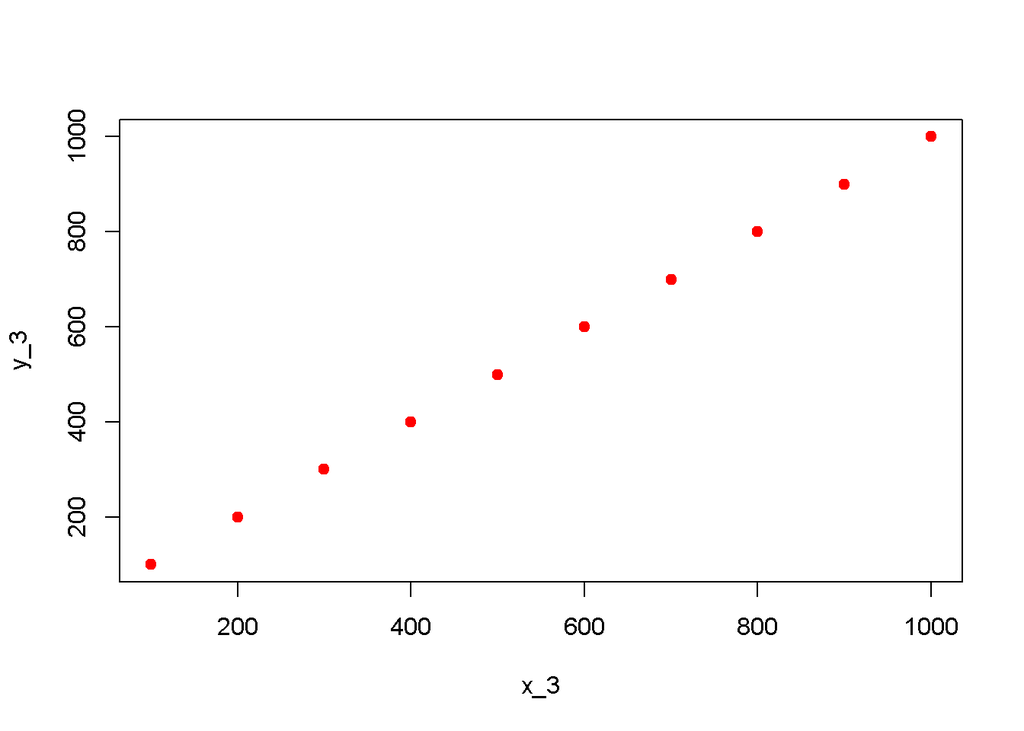

```r
plot(x_3, y_3, pch = 19, col = 'red')
```

i.e. the values of the first datase multiplied by $100$. As we can see from the plot, there clearly is an association beteween $x_3$ and $y_3$, but the interesting fact is that thi sassociation is almost indentical to the first association. Let’s see the plots side by side:

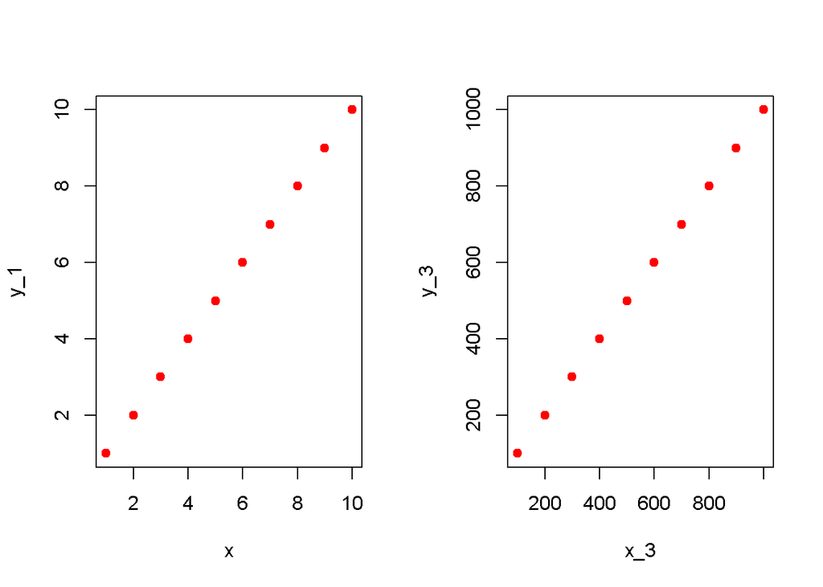

```r
par(mfrow = c(1, 2))
plot(x, y_1, pch = 19, col = 'red')
plot(x_3, y_3, pch = 19, col = 'red')
```

Scales are different, but apart from that, plot and associations are identical. Can we see that from correlation values?

```r
cov_x_y_3 = sum((x_3 - mean(x_3))*(y_3 - mean(y_3)))/(length(x_3) - 1)
cov_x_y_3
```

```
## [1] 91666.67
```

The answer is NO. THe covariance value for the series $x_3$, $y_3$ is $s_{x_3 y_3} = Cov(x_3, y_3)$$=$ 9.166666710^{4} and is different from $Cov(x, y_1)$ $=$ 9.1666667, even if the clearly see that the graphical relationship is the same. This is called the *scale effect* on the covariance: associations that differ only in scale have different covariances values.

In order to avoid this effect the covariance must be *normalized*, i.e. scaled down (or up) in order to become independent from the effects of the magnitude of the values of the data series.

# Correlation

Covariance corrected for the scale effect is called *correlation*:

$r_{x y} = \frac{Cov(x, y)}{s_x s_y}$

where $s_x$ and $s_y$ are the stadard deviations (sample standard deviations in this case) of the two series. For example, the covariance of series $x$ and $y_1$ is:

```r
s_x = sqrt(sum((x - mean(x))^2)/(length(x) - 1))
s_y_1 = sqrt(sum((y_1 - mean(y_1))^2)/(length(y_1) - 1))
cov_x_y_1 = sum((x - mean(x))*(y_1 - mean(y_1)))/(length(y_1) - 1)
r_x_y_1 = cov_x_y_1/(s_x*s_y_1)
```

(Here again we use $N - 1$ to compute statistics since by hypothesis provided data is a *sample* and not the entire population).

So correlation of series $x$ and $y_1$ is: $r_{x y_1}=$ 1. What about the correlation of series $x_3$ and $y_3$? Let’s see:

```r
s_x_3 = sqrt(sum((x_3 - mean(x_3))^2)/(length(x_3) - 1))
s_y_3 = sqrt(sum((y_3 - mean(y_3))^2)/(length(y_3) - 1))
cov_x_y_3 = sum((x_3 - mean(x_3))*(y_3 - mean(y_3)))/(length(y_3) - 1)
r_x_y_3 = cov_x_y_3/(s_x_3*s_y_3)
```

We get: $r_{x_3 y_3}=$ 1, equal to $r_{x y_1}$. That is, correlation is immune from scale effest, telling ud the association between $x$ and $y_1$ is the very same association between $x_3$ and $y_3$ apart from scale. It’s very nice to have a metric of the degree of association between variables that allows us to perform comparisons (i.e. getting what’s common and what is different).

R provides a built in function to compute (sample) correlation between varaibles:

```r
r_x_y_3_R = cor(x_3, y_3)
```

that provides, of course, the very same value: $r_{x_3 y_3}=$ 1.

So let’s summarize all that, providing the plots, from which we get a grasp of the (possible) assocition between the data series and how this association, if any, is summarized by covariance and correlation.

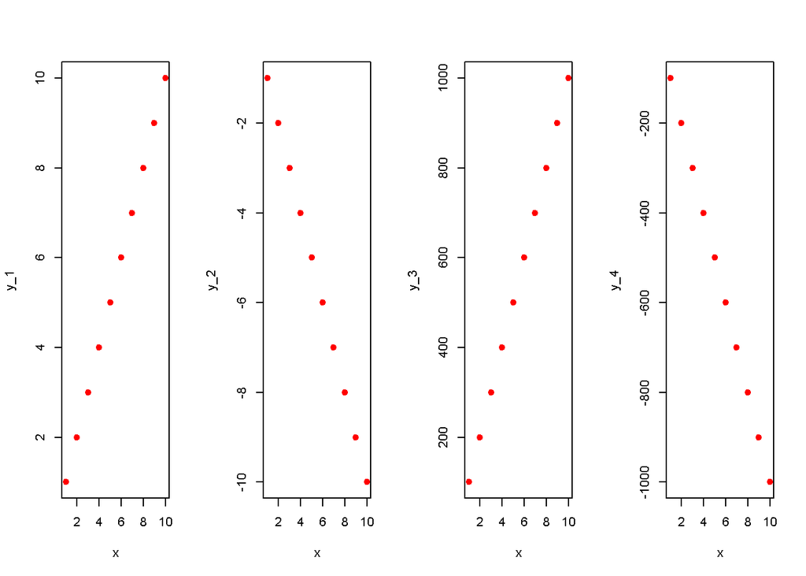

```r
par(mfrow = c(1, 4))
plot(x, y_1, pch = 19, col = "red")
plot(x, y_2, pch = 19, col = "red")
plot(x, y_3, pch = 19, col = "red")
y_4 = -y_3
plot(x, y_4, pch = 19, col = "red")
```

```r
df = data.frame(Series = c(1, 2, 3, 4), Covariance=c(cov(x, y_1), cov(x, y_2), cov(x_3, y_3), cov(x_3, y_4)), Corrrelation=c(cor(x, y_1), cor(x, y_2), cor(x_3, y_3), cor(x_3, y_4)))

kable(df, digits = 2)
```

| Series | Covariance | Corrrelation |
| --- | --- | --- |
| 1 | 9.17 | 1 |
| 2 | -9.17 | -1 |
| 3 | 91666.67 | 1 |
| 4 | -91666.67 | -1 |

Second two plots come from first two series multiplying them by $100$; corariances gets bigger, correlations stay the same.